# Proyecto Bellabeat

Marco Antonio Gonzáles

2024-09-06

## **Bellabeat**

[figure not shown]

[figure not shown]

Urška Sršen, la fundadora nos da la orden de hacer un análisis de data sobre la cantidad de uso que se le da a la aplicación inteligente y en función del análisis realizar recomendación para la campaña de marketing.Para más detalles sobre el proyecto de Bellabeat:Link. A continuación detallaremos y explicaremos nuestro proceso de tratamiendo de la base de datos a través de R lenguaje de programación que hemos escogido para trabajar

## **Data Cleaning**

Esta es una etapa inicial en el cual nos vamos a familiarizar con nuestra dato y observar y corregir datos relevantes para un posterior analisis y eficiente.

#### Lectura de Base de datos

Se descarga las librerias necesarios y se procede a leer la base de datos que nos proporciona el proyecto la cual se denomina *dailyActivity_merged* .

```r
library(tidyverse)
df <- read.csv("C:\\Users\\USUARIO\\Desktop\\proyect_google\\mturkfitbit_export_4.12.16-5.12.16\\Fitabase Data 4.12.16-5.12.16\\dailyActivity_merged.csv", header = TRUE)
```

Antes de proceder con procesar y analizar esta base de datos primero tenemos que empaparnos y contextualizarnos con nuestra data, así como limpiarla, lo cual consiste en verificar si es que hay duplicados o valores nulos en la data lo cual puede impactar y sesgar los resultados generados.

- En primer lugar, queremos saber que columnas tiene nuestra data por lo cual nos apoyamos con la función **columname**.

```r
colnames(df)
```

```
##  [1] "Id"                       "ActivityDate"
##  [3] "TotalSteps"               "TotalDistance"
##  [5] "TrackerDistance"          "LoggedActivitiesDistance"
##  [7] "VeryActiveDistance"       "ModeratelyActiveDistance"
##  [9] "LightActiveDistance"      "SedentaryActiveDistance"
## [11] "VeryActiveMinutes"        "FairlyActiveMinutes"
## [13] "LightlyActiveMinutes"     "SedentaryMinutes"
## [15] "Calories"
```

- También estamos muy interesados en conocer sus dimensiones; es decir, cuantas filas y columnas tiene la data. Nos apoyaremos con la función **dim**.

```r
dim(df)
```

```
## [1] 940  15
```

- Damos una mirada a las primeras observaciones para empaparnos y tener una idea sobre con que datos estamos tratando.

```r
head(df)
```

```
##           Id ActivityDate TotalSteps TotalDistance TrackerDistance
## 1 1503960366    4/12/2016      13162          8.50            8.50
## 2 1503960366    4/13/2016      10735          6.97            6.97
## 3 1503960366    4/14/2016      10460          6.74            6.74
## 4 1503960366    4/15/2016       9762          6.28            6.28
## 5 1503960366    4/16/2016      12669          8.16            8.16
## 6 1503960366    4/17/2016       9705          6.48            6.48
##   LoggedActivitiesDistance VeryActiveDistance ModeratelyActiveDistance
## 1                        0               1.88                     0.55
## 2                        0               1.57                     0.69
## 3                        0               2.44                     0.40
## 4                        0               2.14                     1.26
## 5                        0               2.71                     0.41
## 6                        0               3.19                     0.78
##   LightActiveDistance SedentaryActiveDistance VeryActiveMinutes
## 1                6.06                       0                25
## 2                4.71                       0                21
## 3                3.91                       0                30
## 4                2.83                       0                29
## 5                5.04                       0                36
## 6                2.51                       0                38
##   FairlyActiveMinutes LightlyActiveMinutes SedentaryMinutes Calories
## 1                  13                  328              728     1985
## 2                  19                  217              776     1797
## 3                  11                  181             1218     1776
## 4                  34                  209              726     1745
## 5                  10                  221              773     1863
## 6                  20                  164              539     1728
```

- Otro factor importante es que ver el datatype que tiene cada columna y hacer las correciones de ser necesario.

```r
str(df)
```

```
## 'data.frame':    940 obs. of  15 variables:
##  $ Id                      : num  1.5e+09 1.5e+09 1.5e+09 1.5e+09 1.5e+09 ...
##  $ ActivityDate            : chr  "4/12/2016" "4/13/2016" "4/14/2016" "4/15/2016" ...
##  $ TotalSteps              : int  13162 10735 10460 9762 12669 9705 13019 15506 10544 9819 ...
##  $ TotalDistance           : num  8.5 6.97 6.74 6.28 8.16 ...
##  $ TrackerDistance         : num  8.5 6.97 6.74 6.28 8.16 ...
##  $ LoggedActivitiesDistance: num  0 0 0 0 0 0 0 0 0 0 ...
##  $ VeryActiveDistance      : num  1.88 1.57 2.44 2.14 2.71 ...
##  $ ModeratelyActiveDistance: num  0.55 0.69 0.4 1.26 0.41 ...
##  $ LightActiveDistance     : num  6.06 4.71 3.91 2.83 5.04 ...
##  $ SedentaryActiveDistance : num  0 0 0 0 0 0 0 0 0 0 ...
##  $ VeryActiveMinutes       : int  25 21 30 29 36 38 42 50 28 19 ...
##  $ FairlyActiveMinutes     : int  13 19 11 34 10 20 16 31 12 8 ...
##  $ LightlyActiveMinutes    : int  328 217 181 209 221 164 233 264 205 211 ...
##  $ SedentaryMinutes        : int  728 776 1218 726 773 539 1149 775 818 838 ...
##  $ Calories                : int  1985 1797 1776 1745 1863 1728 1921 2035 1786 1775 ...
```

- Consideramos que es conveniente tener el datatype de columna **ActivityDate** en date y la columna **Id** a caracteres.

```r
df$ActivityDate <- as.Date(df$ActivityDate, format="%m/%d/%Y")
df$Id <- as.character(df$Id)
```

- Verificamos si es que se corrigió correctamente.

```r
str(df)
```

```
## 'data.frame':    940 obs. of  15 variables:
##  $ Id                      : chr  "1503960366" "1503960366" "1503960366" "1503960366" ...
##  $ ActivityDate            : Date, format: "2016-04-12" "2016-04-13" ...
##  $ TotalSteps              : int  13162 10735 10460 9762 12669 9705 13019 15506 10544 9819 ...
##  $ TotalDistance           : num  8.5 6.97 6.74 6.28 8.16 ...
##  $ TrackerDistance         : num  8.5 6.97 6.74 6.28 8.16 ...
##  $ LoggedActivitiesDistance: num  0 0 0 0 0 0 0 0 0 0 ...
##  $ VeryActiveDistance      : num  1.88 1.57 2.44 2.14 2.71 ...
##  $ ModeratelyActiveDistance: num  0.55 0.69 0.4 1.26 0.41 ...
##  $ LightActiveDistance     : num  6.06 4.71 3.91 2.83 5.04 ...
##  $ SedentaryActiveDistance : num  0 0 0 0 0 0 0 0 0 0 ...
##  $ VeryActiveMinutes       : int  25 21 30 29 36 38 42 50 28 19 ...
##  $ FairlyActiveMinutes     : int  13 19 11 34 10 20 16 31 12 8 ...
##  $ LightlyActiveMinutes    : int  328 217 181 209 221 164 233 264 205 211 ...
##  $ SedentaryMinutes        : int  728 776 1218 726 773 539 1149 775 818 838 ...
##  $ Calories                : int  1985 1797 1776 1745 1863 1728 1921 2035 1786 1775 ...
```

Una etapa importante del **Data Cleaning** es verificar que los datos no tenga **duplicados** ni **nulos** pues estos pueden afectar de manera significativa en los resultados y podemos obtener resultados sesgados.

- Verificamos si es que hay **duplicados**. En este caso; no los hay, lo cual es positivo.

```r
sum(duplicated(df))
```

```
## [1] 0
```

- Verificamos la cantidad de **nulos** y la cantidad es cero.

```r
sum(is.na(df))
```

```
## [1] 0
```

## **Procesamiento y Analisis de Datos**

Posterior a estar más empapados nuestra base datos, corregir y verificar; podemos ahora procesar la información para sacar conclusiones y perspectivas que nos ayuden *a posteriori* realizar recomendaciones.Empezamos por ver la información estadística como medias, medianas, cuadrantes, esto es muy relevante. Lo haremos con ayuda de la función **summarize**.

```r
summary(df)
```

```
##       Id             ActivityDate          TotalSteps    TotalDistance
##  Length:940         Min.   :2016-04-12   Min.   :    0   Min.   : 0.000
##  Class :character   1st Qu.:2016-04-19   1st Qu.: 3790   1st Qu.: 2.620
##  Mode  :character   Median :2016-04-26   Median : 7406   Median : 5.245
##                     Mean   :2016-04-26   Mean   : 7638   Mean   : 5.490
##                     3rd Qu.:2016-05-04   3rd Qu.:10727   3rd Qu.: 7.713
##                     Max.   :2016-05-12   Max.   :36019   Max.   :28.030
##  TrackerDistance  LoggedActivitiesDistance VeryActiveDistance
##  Min.   : 0.000   Min.   :0.0000           Min.   : 0.000
##  1st Qu.: 2.620   1st Qu.:0.0000           1st Qu.: 0.000
##  Median : 5.245   Median :0.0000           Median : 0.210
##  Mean   : 5.475   Mean   :0.1082           Mean   : 1.503
##  3rd Qu.: 7.710   3rd Qu.:0.0000           3rd Qu.: 2.053
##  Max.   :28.030   Max.   :4.9421           Max.   :21.920
##  ModeratelyActiveDistance LightActiveDistance SedentaryActiveDistance
##  Min.   :0.0000           Min.   : 0.000      Min.   :0.000000
##  1st Qu.:0.0000           1st Qu.: 1.945      1st Qu.:0.000000
##  Median :0.2400           Median : 3.365      Median :0.000000
##  Mean   :0.5675           Mean   : 3.341      Mean   :0.001606
##  3rd Qu.:0.8000           3rd Qu.: 4.782      3rd Qu.:0.000000
##  Max.   :6.4800           Max.   :10.710      Max.   :0.110000
##  VeryActiveMinutes FairlyActiveMinutes LightlyActiveMinutes SedentaryMinutes
##  Min.   :  0.00    Min.   :  0.00      Min.   :  0.0        Min.   :   0.0
##  1st Qu.:  0.00    1st Qu.:  0.00      1st Qu.:127.0        1st Qu.: 729.8
##  Median :  4.00    Median :  6.00      Median :199.0        Median :1057.5
##  Mean   : 21.16    Mean   : 13.56      Mean   :192.8        Mean   : 991.2
##  3rd Qu.: 32.00    3rd Qu.: 19.00      3rd Qu.:264.0        3rd Qu.:1229.5
##  Max.   :210.00    Max.   :143.00      Max.   :518.0        Max.   :1440.0
##     Calories
##  Min.   :   0
##  1st Qu.:1828
##  Median :2134
##  Mean   :2304
##  3rd Qu.:2793
##  Max.   :4900
```

#### **Segmentación**

```r
df$Categoría <- ifelse(
  df$TotalDistance > 7, "Ágiles",
  ifelse(df$TotalDistance >= 4, "Promedio", "Flojas")
)
```

Observamos si es que efectivamente se creo la nueva categoría

```r
head(df)
```

```
##           Id ActivityDate TotalSteps TotalDistance TrackerDistance
## 1 1503960366   2016-04-12      13162          8.50            8.50
## 2 1503960366   2016-04-13      10735          6.97            6.97
## 3 1503960366   2016-04-14      10460          6.74            6.74
## 4 1503960366   2016-04-15       9762          6.28            6.28
## 5 1503960366   2016-04-16      12669          8.16            8.16
## 6 1503960366   2016-04-17       9705          6.48            6.48
##   LoggedActivitiesDistance VeryActiveDistance ModeratelyActiveDistance
## 1                        0               1.88                     0.55
## 2                        0               1.57                     0.69
## 3                        0               2.44                     0.40
## 4                        0               2.14                     1.26
## 5                        0               2.71                     0.41
## 6                        0               3.19                     0.78
##   LightActiveDistance SedentaryActiveDistance VeryActiveMinutes
## 1                6.06                       0                25
## 2                4.71                       0                21
## 3                3.91                       0                30
## 4                2.83                       0                29
## 5                5.04                       0                36
## 6                2.51                       0                38
##   FairlyActiveMinutes LightlyActiveMinutes SedentaryMinutes Calories Categoría
## 1                  13                  328              728     1985    Ágiles
## 2                  19                  217              776     1797  Promedio
## 3                  11                  181             1218     1776  Promedio
## 4                  34                  209              726     1745  Promedio
## 5                  10                  221              773     1863    Ágiles
## 6                  20                  164              539     1728  Promedio
```

#### **GRAFICO DE BARRAS, LINEAS Y CORRELACIONES**

[figure not shown]

[figure not shown]

```r
ggplot(df, aes(x = Categoría)) +
  geom_bar(aes(y = after_stat(count) / sum(after_stat(count))),
           fill = "skyblue", color = "black") +
  geom_text(
    aes(label = scales::percent(after_stat(count) / sum(after_stat(count)), accuracy = 1)),
    stat = "count",
    vjust = -0.5  # Ajusta la posición vertical del texto
  ) +
  labs(
    x = "Categoría",
    y = "Porcentaje",
    title = "Distribución en función a la Distancia total por Categoría"
  ) +
  scale_y_continuous(labels = scales::percent_format(accuracy = 1), limits = c(0, 1)) +
  theme_minimal()
```

A esta correlación vamos a darle un valor agregado diferenciado cada observación según su categoría a través de colores.

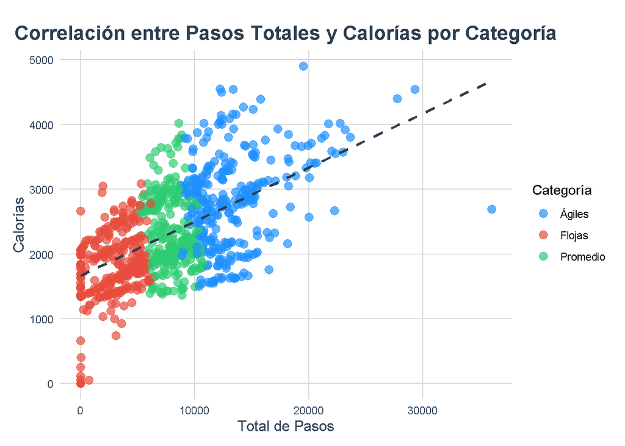

```r
ggplot(df, aes(x = TotalSteps, y = Calories, color = Categoría)) +
  geom_point(size = 3, alpha = 0.7) +  # Puntos más grandes y con transparencia para suavizar el gráfico
  geom_smooth(method = "lm", color = "#2C3E50", linetype = "dashed", se = FALSE) +  # Línea de regresión gris oscuro con estilo de línea discontinua
  labs(
    x = "Total de Pasos",
    y = "Calorías",
    title = "Correlación entre Pasos Totales y Calorías por Categoría",
    color = "Categoría"  # Etiqueta para la leyenda
  ) +
  theme_minimal() +
  scale_color_manual(values = c(
    "Ágiles" = "#1E90FF",  # Azul más sofisticado
    "Promedio" = "#2ECC71",  # Verde menta
    "Flojas" = "#E74C3C"  # Rojo más sobrio
  )) +
  theme(
    plot.title = element_text(hjust = 0.5, color = "#2C3E50", size = 16, face = "bold"),  # Título centrado, con estilo
    axis.title = element_text(color = "#34495E", size = 12),  # Colores suaves en títulos de ejes
    axis.text = element_text(color = "#34495E"),  # Texto de ejes en gris oscuro
    legend.position = "right",  # Leyenda a la derecha
    legend.background = element_rect(fill = "white", color = NA),  # Fondo de leyenda limpio
    legend.key = element_rect(fill = "white", color = NA),  # Fondo de la clave de la leyenda
    panel.grid.major = element_line(color = "gray85"),  # Líneas de la cuadrícula más suaves
    panel.grid.minor = element_blank(),  # Elimina cuadrícula menor
    plot.background = element_rect(fill = "white", color = NA),  # Fondo blanco
    plot.margin = margin(t = 20, r = 10, b = 10, l = 10)  # Ajusta los márgenes del gráfico
  )
```

## **Recomendaciones**

- A la categoría **Flojas** se le podría poner incentivos para mayor uso como recordatorios, mensajes de aliento en función a logros, información sobre riesgos del sedentarismo, etc
- Caso similar se da con el caso de la categoría **Promedio**. Para este sector el marketing seria de fidelización. Recomendariamos realizar rankings de competición, información de progreso respecto a factores como peso, glucosa para generar incentivos como descuentos en productos de la marca.
- Para el caso de las **Ágiles**, se podría realizar el marketing teniendo como elementos de influencia y apoyo tipo sponsor a los usuarios más destacado, siendo elementos de publicidad y embajadores de la marca.